# e1-GWAS-power

Siming Zhao

2026-04-13

## Before the class install R package `pwr`, `tidyverse`

```r
install.packages("pwr")
install.packages("tidyverse")
```

## Workflow overview

In this vignette, we’d like to:

1. Write a simulator to simulate genotype and phenotype under some pre-specified model.
2. Simulate genotype and phenotype using the simulator under the null and alternative.
3. Perform certain hypothesis test.
4. Calculate the power of the test.

Consider a single locus, its genotype is $X$. We pre-specify the model for continuous trait $Y$ and genotype $X$ as

$$Y = \beta X + \epsilon, \epsilon \sim
N(0, \sigma_\epsilon^2)$$
where we assume

- genotype of this locus follows Hardy-Weinberg equilibrium with a pre-specified minor allele frequency.
- residual variance 1.

## Phenotype-genotype simulator

To simulate genotype, we assume the locus is bialleilic and each individual is diploid. So that $X \sim Binomial(2, f)$ with $f$ as minor allele frequency (here we encode minor allele as 1 and major allele as 0). with the linear model for simulate $Y$ above, this basically means we are simulating $Y$ under the additive model.

Given genotype, to simulate phenotype, we need to know $\beta$ and $\sigma_\epsilon^2$.

```r
library(tidyverse)
simulate_genotype = function(maf, num_individuals, num_replicates) {
  # maf: minor allele frequency
  # num_individuals: the number of individuals in each replicates
  # num_replicates: the number of replicates
  # it returns a matrix with num_individuals rows and num_replicates columns
  genotype = matrix(
    rbinom(num_individuals * num_replicates, 2, maf),
    nrow = num_individuals,
    ncol = num_replicates
  )
  return(genotype)
}
simulate_phenotype = function(genotype, beta, sig2epsi) {
  # genotype: each column is one replicate
  # beta: effect size of the linear model
  # sig2epsi: the variance of the noise term
  num_individuals = nrow(genotype)
  num_replicates = ncol(genotype)
  epsilon = matrix(
    rnorm(num_individuals * num_replicates, mean = 0, sd = sqrt(sig2epsi)),
    nrow = num_individuals,
    ncol = num_replicates
  )
  phenotype = genotype * beta + epsilon
  return(phenotype)
}

linear_model_simulator = function(num_replicates, num_individuals, maf, beta, sig2epsi) {
  # simulate genotype
  X = simulate_genotype(maf, num_individuals, num_replicates)

  # simulate phenotype given genotype and model parameters
  Y = simulate_phenotype(X, beta, sig2epsi)
  return(list(Y = Y, X = X))
}
```

## Run the simulator under the null and alternative

- Minor allele frequency is 0.3.
- effect size ($\beta$) of the minor allele 0.05. Effect size is the coefficient in a regression model which measures the regression effect of the locus per copy of the variant allele.
- Variance of residual ($\sigma_\epsilon^2$) = 1.

```r
# specify paramters
nindiv = 1000
nreplicate = 5000
maf = 0.30
b = 0.05
sig2e = 1

# run simulator
## under the alternative
data_alt = linear_model_simulator(nreplicate, nindiv, maf, 0.05, sig2e)
## under the null
data_null = linear_model_simulator(nreplicate, nindiv, maf, 0, sig2e)
```

## Perform hypothesis test

The following chunk of R code implement hypothesis test procedure based on linear regression. Essentially, the R function `calcz` takes genotype `X` and `Y` and returns test statistic z-score.

```r
runassoc = function(X,Y)
{
  pvec = rep(NA,ncol(X))
  bvec = rep(NA,ncol(X))
  for(ss in 1:ncol(X))
  {
    x = X[,ss]
    y = Y[,ss]
    fit = lm(y~x)
    pvec[ss] = summary(fit)$coefficients[2,4]
    bvec[ss] =  summary(fit)$coefficients[2,1]
  }
  list(pvec=pvec, bvec=bvec)
}

p2z = function(b,p)
{
  ## calculate zscore from p-value and sign of effect size
  sign(b) * abs(qnorm(p/2))
}

calcz = function(X,Y)
{
  tempo = runassoc(X,Y)
  p2z(tempo$bvec,tempo$pvec)
}
```

Now that we can calculate test statistics under the null and alternative.

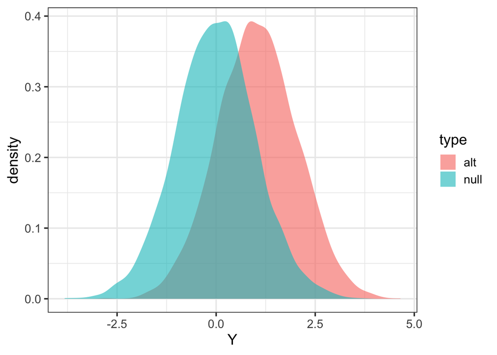

```r
Zalt = calcz(data_alt$X, data_alt$Y)
Znull = calcz(data_null$X, data_null$Y)

tibble(Y = c(Zalt,Znull), type=c(rep("alt",length(Zalt)),rep("null",length(Znull))) ) %>% ggplot(aes(Y,fill=type)) + geom_density(color=NA,alpha=0.6) + theme_bw(base_size = 15)
```

## Calculate power

```r
## define significance level

alpha = 0.01

## find threshold for rejection; we want P(Znull > alpha/2) two-sided

threshold = quantile(Znull, 1 - alpha/2)

## calculate proportion of Zalt above threshold

mean(Zalt > threshold)
```

```
[1] 0.048
```

## check with pwr.r.test function

```r
library(pwr)
calc_r = function(b,maf,sdy) {sdx = sqrt(2 * maf * (1-maf)); sdx * b * sdy}
r = calc_r(b=b,maf=maf,sdy= sqrt(sig2e + b**2*2*maf*(1-maf)))
pwr.r.test(n = nindiv, r= r, sig.level = alpha)
```

```
     approximate correlation power calculation (arctangh transformation)

              n = 1000
              r = 0.03242071
      sig.level = 0.01
          power = 0.06048404
    alternative = two.sided
```

# Reference

Credits go to https://hakyimlab.github.io/hgen471/L4-power.html.